# Projecting knowledge in plots

## NIST and EDA

http://www.itl.nist.gov/div898/handbook/eda/eda.htm

1. what is typical value
2. what is undertainty for typical value
3. what is a good distribution for the set of numbers
4. what is the relationship between factors
5. what are the most important factors
6. is there a structure to the data
7. are there outliers

## NIST comments on assumptions for measurement processes

1. random drawings
2. fixed distribution
3. distribution has fixed location
4. distribution has fixed variation

Univariate or single response variable leads to this model:  
`response = constant + error`

Which then gives this set of assumptions

- data are uncorrelated
- random component has a fixed distribution
- deterministic component is a constant
- random component has a fixed variation

## Useful functions and tools to explore data

1. dim()
2. str()
3. summary()
4. mean, sd, is.na, complete.cases, range
5. summaryBY (aggregate)
6. scatter plot, hist (plus rug), barplot, boxplot, violin plots, pie
7. qqplot, qplot, ggplot2, pairs
8. ordination and PCA plots
9. hive, circular, network plots
10. dendrograms, heatmaps, etc etc

## EDA on a single variable

Generally, on a single variable, we would be interested in:

1. basic summary statistics (count, mean, sd, etc)
2. data issues (missing data, formatting errors, outliers)
3. distribution of data

histograms, boxplots, transformations, word clouds

## EDA on two variables

When we get to two variables, we add to our single variable list, learning about any relationships between the variables.

scatter plots, correlations, conditional means

## EDA on multiple variables

Again, all the above, but now we need more tools to visualize in higher dimension or dimensional reduction techniques.

color, shape, PCA, ordination, network graphs

## Example EDA

This blog is a little commercial for my taste, BUT, he does a great job at EDA imo:

http://sharpsightlabs.com/blog/line-chart-ggplot2-amzn/?utm_source=ssl_email_primary&utm_medium=email&utm_campaign=newsletter

## Plot inspiration

http://www.r-graph-gallery.com

https://flowingdata.com/2016/03/22/comparing-ggplot2-and-r-base-graphics/ https://simplystatistics.org/2016/02/11/why-i-dont-use-ggplot2/ http://varianceexplained.org/r/why-I-use-ggplot2/

## Multipanel plots

I personally find these the most rewarding, but most time consuming plots. I often end up doing them in base R because -I- find the layout easier for me to understand.

Consider a Base R 3 panel plot showing density of a scatter plot in the margins.

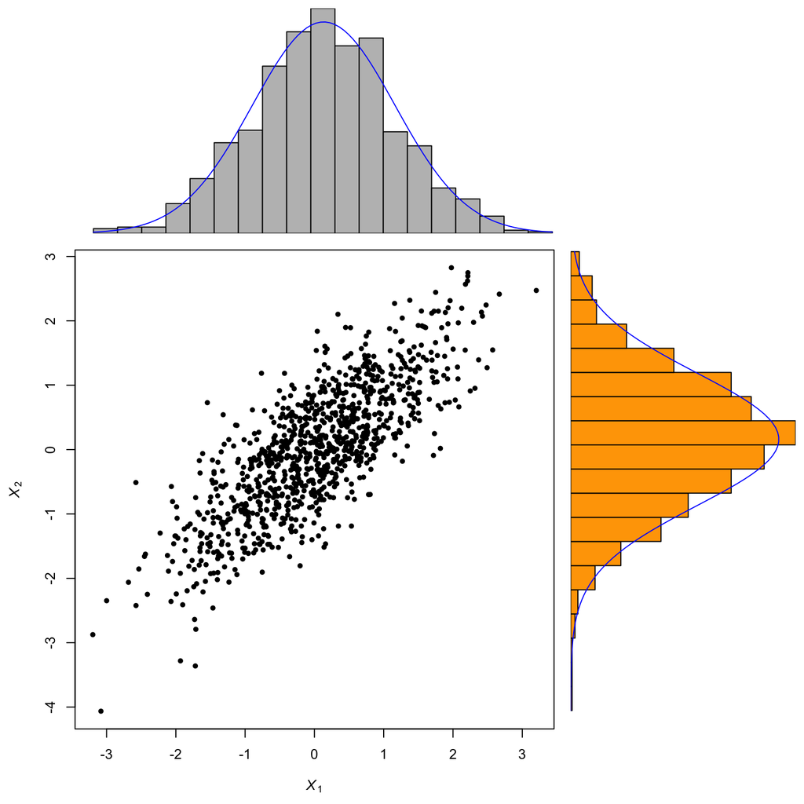

## Multipanel base plot

How do we get to the above? – We manipulate the canvas.

This site has everything needed to make fantastic plots using base functions:

https://www.statmethods.net/advgraphs/layout.html

## Multipanel plots

ggplot2 version:

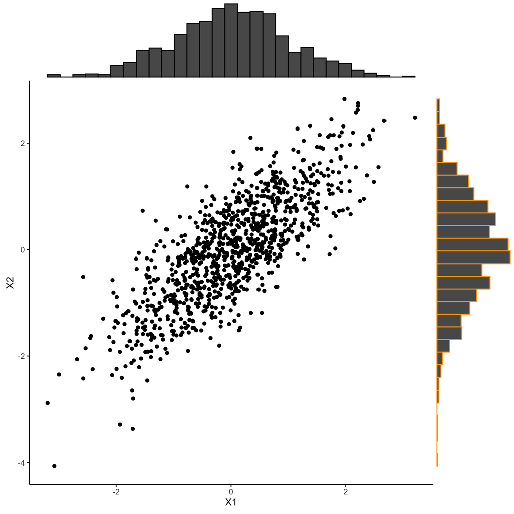

## How do we do multipanel in ggplot2?

From the ggplot2 reference:

All ggplot2 plots begin with a call to ggplot(), supplying default data and aesthethic mappings, specified by aes(). You then add layers, scales, coords and facets with +. To save a plot to disk, use ggsave().

So, it must be something to do with layers. For ggplot2, I recommend:

1. the cheatsheet
2. gridExtra (or one of the many other extension packages to ggplot2)

https://www.r-bloggers.com/ggplot2-easy-way-to-mix-multiple-graphs-on-the-same-page/

## Elements of a good figure

### EDA stage

1. simple to create
2. shows only what you need it to
3. doesn’t take a lot of explaination
4. YOU are the primary audience (at first)
5. has enough detail to give insight

## Elements of a good figure

### Publication stage

1. ok, wow factor
2. shows only what you need it to
3. draws the reader in
4. invokes inquiry
5. is fully self contained with legend AND caption
6. simple is GENERALLY better (meaning less factors in play)
7. all these rules are out the window for art

General good advice:  
http://jaoa.org/article.aspx?articleid=2094515  
Figure caption specifics:  
https://www.physics.ohio-state.edu/~wilkins/writing/Handouts/fig-captions.html  
How to lie with charts:  
https://flowingdata.com/2017/02/09/how-to-spot-visualization-lies/

## Elements of a good figure

### specifics

https://flowingdata.com/2010/07/22/7-basic-rules-for-making-charts-and-graphs/

1. EDA stage, stay simple and investigate oddities
   - outliers, typos, interesting features
2. make a legend if needed (ie you used colors, shapes, etc for a factor)
3. label axes
4. include units
5. keep geometry in check
   - area of circle or square, size of bubble
6. always include sources
7. keep your audience in mind

“To put it simply: tell your story clearly and communicate the data accurately.”

## Homework 8